# Association between number of goals and number of indicators

*David Doret*

*Version 1.0*

*June 2020*

## Introduction

As part of the *IAM Performance Measurement 2020 Survey*, I surveyed IAM professionals about the goals and priorities set for IAM by their organizations.

The original survey question #23 was:

> What are the key strategic goals set for IAM by top management in your organization?

The notebook focuses on data analysis. Its business implications are discussed in a distinct article.

## Setting up the technical environment

To conduct our data analysis, we first need to setup our R technical environment.

```r
#if(!require("ggpubr")) install.packages("ggpubr");
if(!require("VGAM")) install.packages("VGAM");
```

[output not shown]

Some will notice I don’t load libraries. Instead, I prefer to use the unambiguous syntax *package::function*. This makes the code slightly harsher to read but this is a price I am pleased to pay.

## Retrieving the data

Then we need to load our survey data. In accordance with the *Open Source* and *Open Data* spirit of the *Open-Measure* project, all data is publicly available on GitHub. Isn’t that extremely cool, hm?

```r
# Configuration options
# Configuration options
github_folder_url = "https://raw.githubusercontent.com/Open-Measure/Open-Data/master/IAMPerf2020-Dataset/";
survey_url = paste0(github_folder_url, "IAMPerf2020.csv");
q23_goals_url = paste0(github_folder_url, "IAMPerf2020Q23Goals.csv");
q23_priorities_url = paste0(github_folder_url, "IAMPerf2020Q23Priorities.csv");

# Download the survey data from GitHub
# and interpret the CSV to get structured data
survey_data <- read.csv (text = RCurl::getURL(survey_url));
q23_goals <- read.csv (text = RCurl::getURL(q23_goals_url));
q23_priorities <- read.csv (text = RCurl::getURL(q23_priorities_url))

# In the original survey data, we are interested in question #23: IAM Goals.
question_number = 23;
# In the dataset, columns related to this question are prefixed with "Q23R"
question_prefix = paste("Q", question_number, "R", sep = "");
```

## Goals

Let’s have a look at our goal categories. These were compiled from a literature review on IAM and are expected to be largely representative of goals set for IAM by organizations. Complementary research on IAM goals and strategy would be required to uncover new goals but as part of this survey research, we limit our analysis to this sample set.

```r
# Count the number of goal categories (this will be needed later on)
goals_count = nrow(q23_goals);

# In our dataset, the value 5 means "I don't know or not applicable".
priority_na_value = 5;

# N/A values will be managed by the R native NA object.
# For convenience, we can remove it from the list of priorities.
# Of course, we will substitute NA to 5 in the dataset.
# This process will let us work on the real value factors
# while still accounting the NA in an elegant manner.
q23_priorities = q23_priorities[q23_priorities$X != priority_na_value, ];
```

## Question Data

It’s now time to prepare our survey data and look at it.

```r
# In the original survey data, every goal has one corresponding column.
# They are easily recognizable because they are prefixed by Q23R followed
# by an integer value.
iam_goals_columns = paste(question_prefix, 1:goals_count, sep = "");

# Prepare a data.frame with only those columns we are interested in.
question_data = survey_data[,iam_goals_columns];

# Here we are, substitute 5 with NA.
question_data$Q23R1 = ifelse(question_data$Q23R1 == 5, NA, question_data$Q23R1);
question_data$Q23R2 = ifelse(question_data$Q23R2 == 5, NA, question_data$Q23R2);
question_data$Q23R3 = ifelse(question_data$Q23R3 == 5, NA, question_data$Q23R3);
question_data$Q23R4 = ifelse(question_data$Q23R4 == 5, NA, question_data$Q23R4);
question_data$Q23R5 = ifelse(question_data$Q23R5 == 5, NA, question_data$Q23R5);
question_data$Q23R6 = ifelse(question_data$Q23R6 == 5, NA, question_data$Q23R6);
question_data$Q23R7 = ifelse(question_data$Q23R7 == 5, NA, question_data$Q23R7);
question_data$Q23R8 = ifelse(question_data$Q23R8 == 5, NA, question_data$Q23R8);
question_data$Q23R9 = ifelse(question_data$Q23R9 == 5, NA, question_data$Q23R9);
question_data$Q23R10 = ifelse(question_data$Q23R10 == 5, NA, question_data$Q23R10);
question_data$Q23R11 = ifelse(question_data$Q23R11 == 5, NA, question_data$Q23R11);

# Q35: Number of indicators
question_data$Q35 = survey_data$Q35;

# Apply nicely labeled and properly ordered factors.
  question_data$Q23R1 = factor(question_data$Q23R1, levels = q23_priorities$X, labels = q23_priorities$Title, ordered = TRUE, exclude = NA);
  question_data$Q23R2 = factor(question_data$Q23R2, levels = q23_priorities$X, labels = q23_priorities$Title, ordered = TRUE, exclude = NA);
  question_data$Q23R3 = factor(question_data$Q23R3, levels = q23_priorities$X, labels = q23_priorities$Title, ordered = TRUE, exclude = NA);
  question_data$Q23R4 = factor(question_data$Q23R4, levels = q23_priorities$X, labels = q23_priorities$Title, ordered = TRUE, exclude = NA);
  question_data$Q23R5 = factor(question_data$Q23R5, levels = q23_priorities$X, labels = q23_priorities$Title, ordered = TRUE, exclude = NA);
  question_data$Q23R6 = factor(question_data$Q23R6, levels = q23_priorities$X, labels = q23_priorities$Title, ordered = TRUE, exclude = NA);
  question_data$Q23R7 = factor(question_data$Q23R7, levels = q23_priorities$X, labels = q23_priorities$Title, ordered = TRUE, exclude = NA);
  question_data$Q23R8 = factor(question_data$Q23R8, levels = q23_priorities$X, labels = q23_priorities$Title, ordered = TRUE, exclude = NA);
  question_data$Q23R9 = factor(question_data$Q23R9, levels = q23_priorities$X, labels = q23_priorities$Title, ordered = TRUE, exclude = NA);
  question_data$Q23R10 = factor(question_data$Q23R10, levels = q23_priorities$X, labels = q23_priorities$Title, ordered = TRUE, exclude = NA);
  question_data$Q23R11 = factor(question_data$Q23R11, levels = q23_priorities$X, labels = q23_priorities$Title, ordered = TRUE, exclude = NA);
```

## Basic Counting

We have a lot of dropouts in surveys, especially at the beginning of the survey. The increase of dropouts as we advance towards the end of the survey should be studied as well but we’ll keep this for another workbook. For the time being, let’s clarify the size of our sample data and the number of dropouts at question #23.

```r
# Count the number of survey answers.
n = nrow(question_data);

# To correlate Q23 and Q35, I obviously need both questions to be answered.
# For Q23 I count as unanswered when all Goal categorical values are NA.
# For Q35 I count as unanswered when NA.
na_per_row = colSums(apply(question_data[,iam_goals_columns], 1, is.na));
completion_status = ifelse(
  na_per_row == 11 | is.na(question_data$Q35),
  "Incomplete",
  "Complete");
complete = nrow(question_data[completion_status == "Complete",]);
incomplete = nrow(question_data[completion_status == "Incomplete",]);

# Prepare a legend to inform on the sample size and answer rate.
legend_block = paste(
  "n: ", n,
  ", complete: ", complete, " (", round(complete / n * 100), "%)",
  ", incomplete:", incomplete, " (", round(incomplete / n * 100), "%)",
  sep = "");

print(legend_block)
```

```
[1] "n: 201, complete: 35 (17%), incomplete:166 (83%)"
```

Now that we reported the presence of incomplete answers, we may drop these useless records.

```r
question_data = question_data[completion_status == "Complete",];
```

## Following our intuition: a lack of focus

We first need to prepare our data to conduct this analysis.

```r
question_data$NotAGoal = sjmisc::row_count(question_data[,iam_goals_columns], count = "Not a Goal", var = "NotAGoal", append = FALSE)$NotAGoal;
question_data$NiceToHave = sjmisc::row_count(question_data[,iam_goals_columns], count = "Nice to have", var = "NiceToHave", append = FALSE)$NiceToHave;
question_data$SecondaryGoal = sjmisc::row_count(question_data[,iam_goals_columns], count = "Secondary Goal", var = "SecondaryGoal", append = FALSE)$SecondaryGoal;
question_data$PrimaryGoal = sjmisc::row_count(question_data[,iam_goals_columns], count = "Primary Goal", var = "PrimaryGoal", append = FALSE)$PrimaryGoal;

# Compute the total number of priority options selected per row (that is, participant).
question_data$AllPriorities = rowSums(
  question_data[, c("NotAGoal","NiceToHave","SecondaryGoal","PrimaryGoal")]
  );

# It may be interesting to count the number of goals selected per participant.
# No Goal and Nice To Have are not actively pursued goals and are thus
# excluded from the count.
question_data$AllGoal =  rowSums(
  question_data[,c("SecondaryGoal","PrimaryGoal")]
  );

# Let's have a look at our data now.
knitr::kable(dplyr::sample_n(question_data, 10));
```

| Q23R1 | Q23R2 | Q23R3 | Q23R4 | Q23R5 | Q23R6 | Q23R7 | Q23R8 | Q23R9 | Q23R10 | Q23R11 | Q35 | NotAGoal | NiceToHave | SecondaryGoal | PrimaryGoal | AllPriorities | AllGoal |
| --- | --- | --- | --- | --- | --- | --- | --- | --- | --- | --- | --- | --- | --- | --- | --- | --- | --- |
| Primary Goal | Primary Goal | Primary Goal | Primary Goal | Primary Goal | Primary Goal | Primary Goal | Secondary Goal | Secondary Goal | Primary Goal | Primary Goal | 25 | 0 | 0 | 2 | 9 | 11 | 11 |
| Primary Goal | Secondary Goal | Nice to have | Primary Goal | Primary Goal | Secondary Goal | Primary Goal | Nice to have | Secondary Goal | Primary Goal | Secondary Goal | 4 | 0 | 2 | 4 | 5 | 11 | 9 |
| Primary Goal | Nice to have | Nice to have | Secondary Goal | Secondary Goal | Secondary Goal | Secondary Goal | Primary Goal | Nice to have | Primary Goal | Nice to have | 6 | 0 | 4 | 4 | 3 | 11 | 7 |
| Primary Goal | Secondary Goal | NA | Nice to have | Nice to have | NA | NA | NA | NA | NA | Nice to have | 5 | 0 | 3 | 1 | 1 | 5 | 2 |
| Nice to have | Primary Goal | Nice to have | Nice to have | Primary Goal | Secondary Goal | Nice to have | Nice to have | Secondary Goal | Primary Goal | Nice to have | 11 | 0 | 6 | 2 | 3 | 11 | 5 |
| Primary Goal | Primary Goal | Nice to have | Secondary Goal | NA | Nice to have | Nice to have | Primary Goal | Secondary Goal | Secondary Goal | Primary Goal | 32 | 0 | 3 | 3 | 4 | 10 | 7 |
| Primary Goal | Secondary Goal | NA | Primary Goal | Primary Goal | Primary Goal | Primary Goal | NA | Secondary Goal | Primary Goal | Primary Goal | 25 | 0 | 0 | 2 | 7 | 9 | 9 |
| Primary Goal | Primary Goal | Nice to have | Primary Goal | Primary Goal | Secondary Goal | Primary Goal | Nice to have | Primary Goal | Primary Goal | Primary Goal | 20 | 0 | 2 | 1 | 8 | 11 | 9 |
| Nice to have | Secondary Goal | Primary Goal | Nice to have | Secondary Goal | Secondary Goal | Nice to have | NA | Nice to have | Secondary Goal | Nice to have | 5 | 0 | 5 | 4 | 1 | 10 | 5 |
| Secondary Goal | Primary Goal | Nice to have | Secondary Goal | Primary Goal | Nice to have | Primary Goal | Secondary Goal | Primary Goal | Nice to have | Primary Goal | 5 | 0 | 3 | 3 | 5 | 11 | 8 |

```r
NA
```

```r
# The 2 thresholds that delineates our 3 categories
focused_strategy_threshold = 1;
weak_strategy_threshold = 4;

# Assign the strategic categories

question_data$Strategy = ifelse(
  question_data$PrimaryGoal < focused_strategy_threshold,
  "Unknown",
  NA);

question_data$Strategy = ifelse(
  question_data$PrimaryGoal >= focused_strategy_threshold &
  question_data$PrimaryGoal < weak_strategy_threshold,
  "Focused",
  question_data$Strategy);

question_data$Strategy = ifelse(
  question_data$PrimaryGoal >= weak_strategy_threshold,
  "Weak",
  question_data$Strategy);

# Let's have a look at our data now.
knitr::kable(dplyr::sample_n(question_data, 10));
```

| Q23R1 | Q23R2 | Q23R3 | Q23R4 | Q23R5 | Q23R6 | Q23R7 | Q23R8 | Q23R9 | Q23R10 | Q23R11 | Q35 | NotAGoal | NiceToHave | SecondaryGoal | PrimaryGoal | AllPriorities | AllGoal | Strategy |
| --- | --- | --- | --- | --- | --- | --- | --- | --- | --- | --- | --- | --- | --- | --- | --- | --- | --- | --- |
| Nice to have | Secondary Goal | Primary Goal | Nice to have | Secondary Goal | Secondary Goal | Nice to have | NA | Nice to have | Secondary Goal | Nice to have | 5 | 0 | 5 | 4 | 1 | 10 | 5 | Focused |
| Secondary Goal | Primary Goal | Not a Goal | Primary Goal | Primary Goal | Not a Goal | Primary Goal | Nice to have | Nice to have | Primary Goal | Primary Goal | 0 | 2 | 2 | 1 | 6 | 11 | 7 | Weak |
| Primary Goal | Primary Goal | Not a Goal | Nice to have | Not a Goal | Not a Goal | Not a Goal | Primary Goal | Not a Goal | Not a Goal | Not a Goal | 40 | 7 | 1 | 0 | 3 | 11 | 3 | Focused |
| Primary Goal | Primary Goal | Nice to have | Primary Goal | Primary Goal | Secondary Goal | Primary Goal | Nice to have | Primary Goal | Primary Goal | Primary Goal | 20 | 0 | 2 | 1 | 8 | 11 | 9 | Weak |
| Primary Goal | Primary Goal | Not a Goal | Nice to have | Primary Goal | Primary Goal | Primary Goal | Secondary Goal | Nice to have | Secondary Goal | Primary Goal | 5 | 1 | 2 | 2 | 6 | 11 | 8 | Weak |
| Primary Goal | Secondary Goal | Secondary Goal | NA | Primary Goal | NA | Primary Goal | NA | NA | Secondary Goal | NA | 10 | 0 | 0 | 3 | 3 | 6 | 6 | Focused |
| Not a Goal | Not a Goal | Primary Goal | Not a Goal | Not a Goal | Primary Goal | Primary Goal | Nice to have | Not a Goal | Not a Goal | Not a Goal | 5 | 7 | 1 | 0 | 3 | 11 | 3 | Focused |
| Primary Goal | Primary Goal | Primary Goal | Primary Goal | Primary Goal | Primary Goal | Primary Goal | Primary Goal | Secondary Goal | Secondary Goal | Primary Goal | 50 | 0 | 0 | 2 | 9 | 11 | 11 | Weak |
| Primary Goal | Primary Goal | Primary Goal | Secondary Goal | Secondary Goal | Primary Goal | Primary Goal | Nice to have | Secondary Goal | Secondary Goal | Primary Goal | 10 | 0 | 1 | 4 | 6 | 11 | 10 | Weak |
| Primary Goal | Secondary Goal | Nice to have | Primary Goal | Primary Goal | Secondary Goal | Primary Goal | Nice to have | Secondary Goal | Primary Goal | Secondary Goal | 4 | 0 | 2 | 4 | 5 | 11 | 9 | Weak |

```r
NA
```

## Correlation between number of primary strategic goals a number of indicators

First, let’s have a look at the Scatter Plot

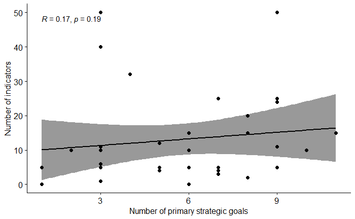

```r
ggpubr::ggscatter(
  question_data, x = "PrimaryGoal", y = "Q35",
  add = "reg.line",
  conf.int = TRUE,
  cor.coef = TRUE,
  cor.method = "kendall",
  xlab = "Number of primary strategic goals",
  ylab = "Number of indicators");
```

```r
cor.test(question_data$PrimaryGoal, question_data$Q35,  method="kendall")
```

```
Cannot compute exact p-value with ties
```

```
    Kendall's rank correlation tau

data:  question_data$PrimaryGoal and question_data$Q35
z = 1.3197, p-value = 0.1869
alternative hypothesis: true tau is not equal to 0
sample estimates:
      tau
0.1683835
```

```r
cor.test(question_data$PrimaryGoal, question_data$Q35,  method = "spearman")
```

```
Cannot compute exact p-value with ties
```

```
    Spearman's rank correlation rho

data:  question_data$PrimaryGoal and question_data$Q35
S = 5436.6, p-value = 0.1675
alternative hypothesis: true rho is not equal to 0
sample estimates:
      rho
0.2385714
```

```r
cor.test(question_data$PrimaryGoal, question_data$Q35, method=c("kendall"))
```

```
Cannot compute exact p-value with ties
```

```
    Kendall's rank correlation tau

data:  question_data$PrimaryGoal and question_data$Q35
z = 1.3197, p-value = 0.1869
alternative hypothesis: true tau is not equal to 0
sample estimates:
      tau
0.1683835
```

# References

I list here a bunch of articles that have been inspiring or helpful while writing this notebook.

- http://www.sthda.com/english/wiki/correlation-test-between-two-variables-in-r
- https://journals.sagepub.com/doi/pdf/10.1177/8756479308317006
- https://www.rdocumentation.org/packages/VGAM/versions/1.1-2/topics/kendall.tau